# Interroger Lexique avec R

Christophe Pallier

Ce document montre comment interroger et manipuler la base [Lexique](http://www.lexique.org) hors-ligne avec le logiciel R

Note: Il fait parti du cours [Programmation pour les Sciences Cognitives](https://chrplr.github.io/PCBS/). Merci de signaler d’éventuelles erreurs à christophe@pallier.org

## Installation

1. S’ils ne sont pas déjà installés sur votre ordinateur, vous devrez installer les deux logiciels (en acceptant les options par défaut):
   - [R](https://cran.r-project.org/)
   - [RStudio Desktop](https://www.rstudio.com/products/rstudio/#Desktop).
2. Démarrer le programme **Rstudio** puis, dans l’onglet **Console** situé dans la fenêtre en bas à gauche, copier la ligne suivante puis appuyez sur ‘Entrée’

```r
install.packages(c('rjson', 'tidyverse'))
```

Laissez RStudio se débrouiller (mais vous devrez peut-être sélectionner un serveur).

Puis créez un nouveau projet (Menu `File/New Project/New Directory/New project`) que vous nommerez *lexique*.

Vous êtes prêt ! Vous n’aurez plus jamais à refaire ces étapes.

## Chargement de la table *lexique*

Tout se déroule dans le logiciel **RStudio**.

Dans le menu `File`, ouvrez le projet *lexique* créé dans la section précédente (Après un redémarrage de RStudio, vous pouvez utiliser le menu `File/Recent Projects` pour retrouver ce projet).

- Cliquez le menu `File/New File/R Notebook`: Un document “Untitled” apparait dans la fenêtre en haut à gauche. C’est dans ce document que nous allons entrer du code R.
- Commencez par supprimer tout ce que se trouve après la ligne 4 (ne conservez que les 4 premières lignes).
- Placez le curseur sur la ligne 5 (juste après la ligne contenant ‘—’), et cliquez sur le bouton *Insert* puis choisisez *R* (ou appuyer sur *Ctrl+Alt+I*).

  Copiez les lignes suivantes à l’intérieur du bloc de code qui vient d’être créé.

```r
require(tidyverse)
require(rjson)
source('https://raw.githubusercontent.com/chrplr/openlexicon/master/datasets-info/fetch_datasets.R')
lexique <- get_lexique383()
```

La fenêtre `Rstudio` doit ressembler à la figure 1.

[figure not shown]

Téléchargment de Lexique

En faisant bien attention que le curseur soit *à l’intérieur du bloc de code*, cliquez sur `Run/Run current chunk` (ou bien appuyez sur la petite *flèche verte*, ou bien encore sur les touches *Ctrl-Shift-Enter*).

La variable `lexique` doit maintenant apparaitre dans l’onglet **Environment** en haut à droite ; Vous pouvez cliquez dessus pour consulter la table.

## Exploration de la distribution des fréquences

Supprimons les mots très rares, de fréquence d’occurrence inférieure à 0.5 par million dans le corpus des livres :

```r
lexique1 <- subset(lexique, freqlivres > 0.5)
lexique1$logfreq <- log10(lexique1$freqlivres)
```

Puis calculons l’histogramme des fréquences, et affichons le sur un graphique avec des axes logarithmiques:

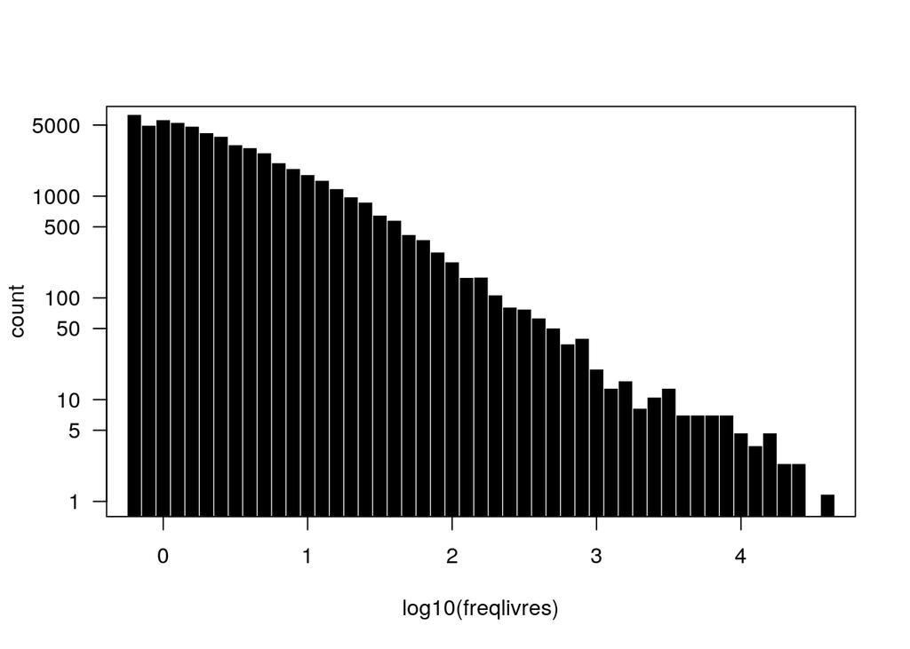

```r
with(lexique1, {
  histdata <- hist(logfreq, plot=FALSE, nclass=50)
  plot(histdata$breaks[-1], histdata$count, log="y", type='h', lwd=10, lend=2, las=1, xlab='log10(freqlivres)', ylab='count')
  }
)
```

Note: On retrouve la [loi de Zipf](https://fr.wikipedia.org/wiki/Loi_de_Zipf), c’est à dire une relation à peu près linéaire sur ce graphique log-log, qui reflète une distribution en loi de puissance.

## Recherche de mots

Supposons que vous vouliez extraire les lignes de la table lexique correspondant, par exemple, aux mots *bateau, avion, maison, arbre*.

Créez un bloc de code (Ctrl-Alt-I) et copiez-y le code suivant :

```r
items <- c('bateau', 'avion', 'maison', 'arbre')

selection <- subset(lexique, ortho %in% items)

head(selection)
```

| ortho | phon | lemme | cgram | genre | nombre | freqlemfilms2 | freqlemlivres | freqfilms2 | freqlivres | infover | nbhomogr | nbhomoph | islem | nblettres | nbphons | cvcv | p_cvcv | voisorth | voisphon | puorth | puphon | syll | nbsyll | cv-cv | orthrenv | phonrenv | orthosyll | cgramortho | deflem | … |
| --- | --- | --- | --- | --- | --- | --- | --- | --- | --- | --- | --- | --- | --- | --- | --- | --- | --- | --- | --- | --- | --- | --- | --- | --- | --- | --- | --- | --- | --- | --- |
| arbre | aRbR | arbre | NOM | m | s | 81.69 | 208.58 | 49.29 | 67.16 | NA | 1 | 2 | 1 | 5 | 4 | VCCCV | VCCC | 2 | 2 | 5 | 4 | aRbR | 1 | VCCC | erbra | RbRa | ar-bre | NOM | 100 | … |
| avion | avj§ | avion | NOM | m | s | 128.35 | 78.04 | 105.54 | 46.82 | NA | 1 | 4 | 1 | 5 | 4 | VCVVC | VCYV | 1 | 6 | 5 | 4 | a-vj§ | 2 | V-CYV | noiva | §jva | a-vion | NOM | 100 | … |
| bateau | bato | bateau | NOM | m | s | 124.82 | 82.36 | 106.55 | 61.22 | NA | 1 | 2 | 1 | 6 | 4 | CVCVVV | CVCV | 0 | 17 | 6 | 4 | ba-to | 2 | CV-CV | uaetab | otab | ba-teau | NOM | 95 | … |
| maison | mEz§ | maison | NOM | NA | s | 605.75 | 575.34 | 570.30 | 461.55 | NA | 1 | 2 | 1 | 6 | 4 | CVVCVC | CVCV | 2 | 8 | 6 | 4 | mE-z§ | 2 | CV-CV | nosiam | §zEm | mai-son | NOM | 93 | … |

Exécutez ce code (Ctrl-Shift-Enter). La variable `selection` doit contenir les lignes pertinentes. Vous pouvez inspecter son contenu en cliquant sur son nom dans l’onglet **Environment** situé dans la fenêtre en haut à droite de RStudio.

Pour sauvegarder les résultats obtenus dans un fichier, exéctuez la commande suivante:

```r
write_tsv(selection, 'selection.tsv')
```

Cela doit créer un fichier `selection.tsv` dans le répertoire du projet (*lexique*).

Notez que les fichiers ayant l’extension `tsv` (tab-separated-values) peuvent être [ouverts avec Excel](https://rievent.zendesk.com/hc/en-us/articles/360000029172-FAQ-How-do-I-open-a-tsv-file-in-Excel-), ou OpenOffice Calc, ou même avec n’importe quel éditeur de texte. Note: le package `readr` de R fournit aussi des fonctions `write_excel_csv` et `write_excel_csv2` qui peuvent intéresser certains.

Si vous avez une liste de mots plus longue, il serait fastidieux d’écrire la ligne `items <- ...`. Plus simplement vous pouvez utiliser:

```r
items = scan(what='characters')
```

Et coller la liste de mots. Pour finir la liste, entrez une ligne vide (en appuyant deux fois successivement sur la touche *Entrée*), puis, à nouveau:

```r
selection <- subset(lexique, ortho %in% items)
```

Comme la fonction `scan` permet aussi de lire la liste dans un fichier externe, si vous avez une liste de mots dans fichier `liste.txt`, vous pouvez extraire les lignes de lexique qui contiennent spécifiquement ces mots avec le code suivant:

```r
liste <- scan('liste.txt', what='characters')
selection <- subset(lexique, ortho %in% liste)
```

## Sélection par critères

```r
selection = subset(lexique, cgram=='NOM' & nombre != 'p' & nblettres==5 & freqlivres > 10 & freqlivres < 100)
head(selection)
```

| ortho | phon | lemme | cgram | genre | nombre | freqlemfilms2 | freqlemlivres | freqfilms2 | freqlivres | infover | nbhomogr | nbhomoph | islem | nblettres | nbphons | cvcv | p_cvcv | voisorth | voisphon | puorth | puphon | syll | nbsyll | cv-cv | orthrenv | phonrenv | orthosyll | cgramortho | deflem | … |
| --- | --- | --- | --- | --- | --- | --- | --- | --- | --- | --- | --- | --- | --- | --- | --- | --- | --- | --- | --- | --- | --- | --- | --- | --- | --- | --- | --- | --- | --- | --- |
| abîme | abim | abîme | NOM | m | s | 6.01 | 20.61 | 5.03 | 14.59 | NA | 2 | 6 | 1 | 5 | 4 | VCVCV | VCVC | 3 | 9 | 5 | 4 | a-bim | 2 | V-CVC | emîba | miba | a-bî-me | NOM,VER | 100 | … |
| achat | aSa | achat | NOM | m | s | 9.75 | 16.96 | 5.20 | 10.95 | NA | 1 | 3 | 1 | 5 | 3 | VCCVC | VCV | 0 | 18 | 5 | 3 | a-Sa | 2 | V-CV | tahca | aSa | a-chat | NOM | 92 | … |
| acier | asje | acier | NOM | m | s | 13.88 | 34.46 | 13.85 | 33.38 | NA | 1 | 4 | 1 | 5 | 4 | VCVVC | VCYV | 1 | 5 | 4 | 4 | a-sje | 2 | V-CYV | reica | ejsa | a-cier | NOM | 91 | … |
| adieu | adj2 | adieu | NOM | m | s | 44.44 | 38.04 | 36.86 | 27.50 | NA | 2 | 3 | 1 | 5 | 4 | VCVVV | VCYV | 0 | 1 | 4 | 4 | a-dj2 | 2 | V-CYV | ueida | 2jda | a-dieu | NOM,ONO | 100 | … |
| affût | afy | affût | NOM | m | s | 1.42 | 11.35 | 1.36 | 10.81 | NA | 1 | 2 | 1 | 5 | 3 | VCCVC | VCV | 0 | 7 | 5 | 3 | a-fy | 2 | V-CV | tûffa | yfa | af-fût | NOM | 75 | … |
| agent | aZ@ | agent | NOM | m | s | 117.90 | 39.26 | 92.42 | 22.50 | NA | 1 | 2 | 1 | 5 | 3 | VCVCC | VCV | 4 | 13 | 5 | 3 | a-Z@ | 2 | V-CV | tnega | @Za | a-gent | NOM | 100 | … |

Le symbole `&` signifie ‘et’. L’expression `nombre != p` signitif que la valeur dans la colonne *nombre* ne doit pas être `p`.

## Sélection par “pattern”

### Les expressions régulières

Les expressions réulières, ou **regex**, sont des “patterns” qui permettent de rechercher des mots ayant certaines propriétés. Par exemple n’importe `a.b` désigne un mot contenant un `a` et un `b` séparés par une lettre quelconque. Voici d’autre exemples:

- **`^maison$`** : recherche le mot “maison” exactement
- **`^anti`** : recherche tous les mots commençant par “anti”
- **`^(jour|nuit|matin|soir)$`** : “jour” ou “nuit” ou “matin” ou “soir” (permet de rechercher une liste de mots)
- **`ion`** : recherche les mots qui contiennent la chaine “ion” dans n’importe quelle position
- **`ion$`** : mots se terminant par “ion”
- **`^pr`** : mots commençant par “pr”
- **`^p..r`$** : mots de quatre lettres commençant par “p”, finisant pas “r”
- **`^p.*r$`** : mots commencant par ‘”p’ et finissant par “r”
- **`[aeiou][aeiou]`** : mots contenant 2 voyelles successives
- **`^[aeiou]`** : mots commençant par une voyelle
- **`^[^aeriou]`** : mots ne commençant pas par une voyelle

Il existe de nombreux tutoriaux sur les regex sur le web, notamment http://regextutorials.com/intro.html

Une expression régulière décrit un automate de transitions à états finis. Le site https://regexper.com/ vous permet de visualiser l’automate associé à une regex. Par exemple `[ptk].*[aiou][aiou].?ion$` correspond à l’automate fini:

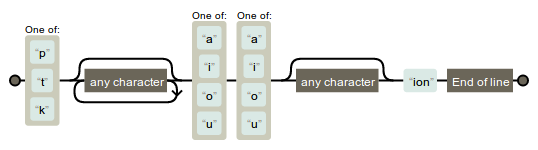

### Recherches dans R avec grepl

R permet d’effectuer des recherches par pattern grâce à la fonction `grepl`. La syntaxe est `grepl(`*regex*, *variable*`)` pour rechercher les lignes où la variable “matche” la regex (Voir la [doc R de grepl](https://stat.ethz.ch/R-manual/R-devel/library/base/html/grep.html).

Cette fonction permet de localiser les lignes qui ‘matchent’ une expression, ou bien, en la niant avec le signe `!`, de supprimer des lignes qui matchent un pattern.

Voici quelques exemples:

- Pour obtenir tous les mots qui finissent par `tion` :

```r
lexique %>% filter(grepl("tion$", ortho)) -> selection2
head(selection2)
```

| ortho | phon | lemme | cgram | genre | nombre | freqlemfilms2 | freqlemlivres | freqfilms2 | freqlivres | infover | nbhomogr | nbhomoph | islem | nblettres | nbphons | cvcv | p_cvcv | voisorth | voisphon | puorth | puphon | syll | nbsyll | cv-cv | orthrenv | phonrenv | orthosyll | cgramortho | deflem | … |
| --- | --- | --- | --- | --- | --- | --- | --- | --- | --- | --- | --- | --- | --- | --- | --- | --- | --- | --- | --- | --- | --- | --- | --- | --- | --- | --- | --- | --- | --- | --- |
| abdication | abdikasj§ | abdication | NOM | f | s | 0.05 | 1.96 | 0.05 | 1.82 | NA | 1 | 2 | 1 | 10 | 9 | VCCVCVCVVC | VCCVCVCYV | 0 | 0 | 5 | 6 | ab-di-ka-sj§ | 4 | VC-CV-CV-CYV | noitacidba | §jsakidba | ab-di-ca-tion | NOM | 70 | … |
| abduction | abdyksj§ | abduction | NOM | f | s | 0.05 | 0.00 | 0.05 | 0.00 | NA | 1 | 1 | 1 | 9 | 8 | VCCVCCVVC | VCCVCCYV | 1 | 0 | 7 | 6 | ab-dyk-sj§ | 3 | VC-CVC-CYV | noitcudba | §jskydba | NA | NOM | NA | … |
| aberration | abERasj§ | aberration | NOM | f | s | 1.16 | 4.46 | 0.89 | 3.31 | NA | 1 | 2 | 1 | 10 | 8 | VCVCCVCVVC | VCVCVCYV | 0 | 0 | 7 | 5 | a-bE-Ra-sj§ | 4 | V-CV-CV-CYV | noitarreba | §jsaREba | a-ber-ra-tion | NOM | 95 | … |
| abjection | abZEksj§ | abjection | NOM | f | s | 0.51 | 2.30 | 0.37 | 2.16 | NA | 1 | 2 | 1 | 9 | 8 | VCCVCCVVC | VCCVCCYV | 1 | 1 | 7 | 6 | ab-ZEk-sj§ | 3 | VC-CVC-CYV | noitcejba | §jskEZba | ab-jec-tion | NOM | 85 | … |
| abjuration | abZyRasj§ | abjuration | NOM | f | s | 0.00 | 0.47 | 0.00 | 0.41 | NA | 1 | 2 | 1 | 10 | 9 | VCCVCVCVVC | VCCVCVCYV | 1 | 1 | 6 | 6 | ab-Zy-Ra-sj§ | 4 | VC-CV-CV-CYV | noitarujba | §jsaRyZba | ab-ju-ra-tion | NOM | 72 | … |
| ablation | ablasj§ | ablation | NOM | f | s | 0.45 | 1.35 | 0.43 | 1.28 | NA | 1 | 2 | 1 | 8 | 7 | VCCVCVVC | VCCVCYV | 2 | 2 | 7 | 5 | a-bla-sj§ | 3 | V-CCV-CYV | noitalba | §jsalba | a-bla-tion | NOM | 91 | … |

Encore une fois, vous pouvez sauvegarder ces résultats avec:

```r
write_tsv(selection2, 'mots-en-tion.tsv')
```

- Pour lister tous les mots contenant un cluster de consonnes plosives, mais pas debut de mot:

```r
lexique %>% filter(grepl('.[ptkbdg][ptkbdg]', phon)) -> selection3
head(selection3)
```

| ortho | phon | lemme | cgram | genre | nombre | freqlemfilms2 | freqlemlivres | freqfilms2 | freqlivres | infover | nbhomogr | nbhomoph | islem | nblettres | nbphons | cvcv | p_cvcv | voisorth | voisphon | puorth | puphon | syll | nbsyll | cv-cv | orthrenv | phonrenv | orthosyll | cgramortho | deflem | … |
| --- | --- | --- | --- | --- | --- | --- | --- | --- | --- | --- | --- | --- | --- | --- | --- | --- | --- | --- | --- | --- | --- | --- | --- | --- | --- | --- | --- | --- | --- | --- |
| abdication | abdikasj§ | abdication | NOM | f | s | 0.05 | 1.96 | 0.05 | 1.82 | NA | 1 | 2 | 1 | 10 | 9 | VCCVCVCVVC | VCCVCVCYV | 0 | 0 | 5 | 6 | ab-di-ka-sj§ | 4 | VC-CV-CV-CYV | noitacidba | §jsakidba | ab-di-ca-tion | NOM | 70 | … |
| abdications | abdikasj§ | abdication | NOM | f | p | 0.05 | 1.96 | 0.00 | 0.14 | NA | 1 | 2 | 0 | 11 | 9 | VCCVCVCVVCC | VCCVCVCYV | 0 | 0 | 0 | 6 | ab-di-ka-sj§ | 4 | VC-CV-CV-CYV | snoitacidba | §jsakidba | ab-di-ca-tions | NOM | 70 | … |
| abdiqua | abdika | abdiquer | VER | NA | NA | 0.47 | 2.77 | 0.00 | 0.20 | ind:pas:3s; | 1 | 1 | 0 | 7 | 6 | VCCVCVV | VCCVCV | 2 | 3 | 0 | 0 | ab-di-ka | 3 | VC-CV-CV | auqidba | akidba | ab-di-qua | VER | 100 | … |
| abdiquai | abdikE | abdiquer | VER | NA | NA | 0.47 | 2.77 | 0.00 | 0.07 | ind:pas:1s; | 1 | 4 | 0 | 8 | 6 | VCCVCVVV | VCCVCV | 0 | 3 | 0 | 0 | ab-di-kE | 3 | VC-CV-CV | iauqidba | Ekidba | ab-di-quai | VER | 100 | … |
| abdiquaient | abdikE | abdiquer | VER | NA | NA | 0.47 | 2.77 | 0.00 | 0.07 | ind:imp:3p; | 1 | 4 | 0 | 11 | 6 | VCCVCVVVVCC | VCCVCV | 0 | 3 | 0 | 0 | ab-di-kE | 3 | VC-CV-CV | tneiauqidba | Ekidba | ab-di-quaient | VER | 100 | … |
| abdiquais | abdikE | abdiquer | VER | NA | NA | 0.47 | 2.77 | 0.00 | 0.14 | ind:imp:1s; | 1 | 4 | 0 | 9 | 6 | VCCVCVVVC | VCCVCV | 1 | 3 | 0 | 0 | ab-di-kE | 3 | VC-CV-CV | siauqidba | Ekidba | ab-di-quais | VER | 100 | … |

- L’opérateur `filter`peut être appeler plusieurs fois pour affiner progressivement la recherche.

  Par exemple, pour obtenir tous les mots de 8 lettres qui ne finissent pas `ent`:

```r
lexique %>% filter(nblettres == 8) %>% filter(!grepl("ent$", ortho)) -> selection4
head(selection4)
```

| ortho | phon | lemme | cgram | genre | nombre | freqlemfilms2 | freqlemlivres | freqfilms2 | freqlivres | infover | nbhomogr | nbhomoph | islem | nblettres | nbphons | cvcv | p_cvcv | voisorth | voisphon | puorth | puphon | syll | nbsyll | cv-cv | orthrenv | phonrenv | orthosyll | cgramortho | deflem | … |
| --- | --- | --- | --- | --- | --- | --- | --- | --- | --- | --- | --- | --- | --- | --- | --- | --- | --- | --- | --- | --- | --- | --- | --- | --- | --- | --- | --- | --- | --- | --- |
| a giorno | adZjORno | a giorno | ADV | NA | NA | 0.00 | 0.27 | 0.00 | 0.27 | NA | 1 | 2 | 1 | 8 | 8 | V CVVCCV | VCCYVCCV | 1 | 0 | 3 | 4 | ad-ZjOR-no | 3 | VC-CYVC-CV | onroig a | onROjZda | a gior-no | ADV | NA | … |
| a priori | apRijoRi | a priori | ADV | NA | NA | 1.04 | 3.85 | 0.63 | 2.57 | NA | 2 | 3 | 1 | 8 | 8 | V CCVVCV | VCCVYVCV | 1 | 0 | 4 | 5 | a-pRi-jo-Ri | 4 | V-CCV-YV-CV | iroirp a | iRojiRpa | a prio-ri | ADV,NOM | NA | … |
| a priori | apRijoRi | a priori | NOM | m | NA | 0.41 | 0.47 | 0.41 | 0.47 | NA | 2 | 3 | 1 | 8 | 8 | V CCVVCV | VCCVYVCV | 1 | 0 | 4 | 5 | a-pRi-jo-Ri | 4 | V-CCV-YV-CV | iroirp a | iRojiRpa | a prio-ri | ADV,NOM | 93 | … |
| abaissai | abEsE | abaisser | VER | NA | NA | 4.93 | 18.04 | 0.10 | 0.07 | ind:pas:1s; | 1 | 3 | 0 | 8 | 5 | VCVVCCVV | VCVCV | 0 | 5 | 0 | 0 | a-bE-sE | 3 | V-CV-CV | iassiaba | EsEba | a-bais-sai | VER | 100 | … |
| abaisser | abese | abaisser | VER | NA | NA | 4.93 | 18.04 | 1.09 | 2.91 | inf; | 1 | 10 | 1 | 8 | 5 | VCVVCCVC | VCVCV | 2 | 2 | 8 | 5 | a-be-se | 3 | V-CV-CV | ressiaba | eseba | a-bais-ser | VER | 100 | … |
| abaisses | abEs | abaisser | VER | NA | NA | 4.93 | 18.04 | 0.16 | 0.07 | ind:pre:2s; | 1 | 6 | 0 | 8 | 4 | VCVVCCVC | VCVC | 3 | 4 | 0 | 4 | a-bEs | 2 | V-CVC | sessiaba | sEba | a-bais-ses | VER | 100 | … |

# Chargement d’autres tables d’OpenLexicon

Le projet [OpenLexicon](https://github.com/chrplr/openlexicon) comprend de nombreuses tables lexicales (voir https://chrplr.github.io/openlexicon/datasets-info/).

Pour accéder à ces tables, vous pouvez utiliser la fonction `fetch_datatset` définie dans https://raw.githubusercontent.com/chrplr/openlexicon/master/datasets-info/fetch_datasets.R.

Elle télécharge automatiquement les bases de données définies dans les fichiers .json listés dans https://raw.githubusercontent.com/chrplr/openlexicon/master/datasets-info/_json.

Par exemple, pour charger la table SUBTLEX-US:

````
```r
source('https://raw.githubusercontent.com/chrplr/openlexicon/master/datasets-info/fetch_datasets.R')
subtlexus <- readRDS(fetch_dataset('SUBTLEX-US', format='rds')$datatables[[1]])
```

```
## Warning in fetch_dataset("SUBTLEX-US", format = "rds"): Downloading in /
## home/cp983411/openlexicon_datasets/SUBTLEXus.rds
```

```
## Warning in fetch_dataset("SUBTLEX-US", format = "rds"): You already have
## the file /home/cp983411/openlexicon_datasets/SUBTLEXus.rds which is up to
## date.
```
````